# Project 1

Heather Copley & Andy Johnson

2023-08-29

# Objective

The goal of this project is to write functions that will process and visualize data sets that come in a certain form from the US Census Bureau.

# Data Processing without Functions

First we will parse and transform the data without creating functions to better understand the tasks we want to perform. One of the data sets can be read from csv from the following link:

```r
sheet1 <- read_csv("https://www4.stat.ncsu.edu/~online/datasets/EDU01a.csv")
```

## Select Columns

We want to select the following columns:

- Area_name (rename as area_name)
- STCOU
- Any column that ends in “D”

```r
#select area_name, STCOU, and columns ending with D
data_selections <- sheet1 %>%
    select(area_name = Area_name, STCOU, ends_with('D'))
```

## Pivot Data from Wide to Long

Next we pivot the data from a wide format to a long format where each row has only one enrollment value for the area.

```r
#pivot columns ending with D into 2 columns
#one for the enrollment code and
#one for the values
data_pivot <- data_selections %>%
    pivot_longer(cols = ends_with('D'),
                 names_to = 'Enrollment_code',
                 values_to = 'Enrollment_value')
```

## Extract Year and Measurement

Now we extract the year and the measurement from the enrollment code.

The enrollment code follows a pattern:

- The first three characters are the survey
- The next four are the type of value from the survey
- The last two digits prior to the “D” represent the year

```r
#extract the year (digits 8 & 9) and format as a 4 digit year
#extract the measurement (the first 7 characters)
data_extract <- data_pivot %>%
    mutate(year = year(as.Date(substr(Enrollment_code, 8,9), format = '%y')),
           measurement = substr(Enrollment_code, 1, 7))
```

## Split Data

Next we split the data into two data sets, one for county-level data and one for non-county (state & national) data. We also assign classes to each data set to enable class-specific plotting later in the project.

```r
#get the county data
county_data <- data_extract %>%
    filter(str_detect(area_name, ',' ))
#assign county class
class(county_data) <- c('county', class(county_data))

#get the non-county data
non_county_data <- data_extract %>%
    filter(!str_detect(area_name, ',' ))
##assign state class
class(non_county_data) <- c('state', class(non_county_data))
```

## Extract State

For the county data, we want to extract the two-letter state abbreviation for each row.

```r
#extract state names
county_data <- county_data %>%
    mutate(state = substr(area_name, nchar(area_name) -1, nchar(area_name)))
```

## Assign Divisions

For the state data, we want to assign divisions based on the divisions found [here](https://en.wikipedia.org/wiki/List_of_regions_of_the_United_States)

```r
## Assign divisions based on the state
#if there is no state assign "ERROR"

non_county_data <- non_county_data %>%
    mutate(division = case_when(area_name %in% toupper(c('Connecticut',
                                                         'Maine',
                                                         'Massachusetts',
                                                         'New Hampshire',
                                                         'Rhode Island',
                                                         'Vermont')) ~ 'Division 1',
                                area_name %in% toupper(c('New Jersey',
                                                         'New York',
                                                         'Pennsylvania')) ~ 'Division 2',
                                area_name %in% toupper(c('Illinois',
                                                         'Indiana',
                                                         'Michigan',
                                                         'Ohio',
                                                         'Wisconsin')) ~ 'Division 3',
                                area_name %in% toupper(c('Iowa',
                                                         'Kansas',
                                                         'Minnesota',
                                                         'Missouri',
                                                         'Nebraska',
                                                         'North Dakota',
                                                         'South Dakota')) ~ 'Division 4',
                                area_name %in% toupper(c('Delaware',
                                                         'Florida',
                                                         'Georgia',
                                                         'Maryland',
                                                         'North Carolina',
                                                         'South Carolina',
                                                         'Virginia',
                                                         'District of Columbia',
                                                         'West Virginia')) ~ 'Division 5',
                                area_name %in% toupper(c('Alabama',
                                                         'Kentucky',
                                                         'Mississippi',
                                                         'Tennessee')) ~ 'Division 6',
                                area_name %in% toupper(c('Arkansas',
                                                         'Louisiana',
                                                         'Oklahoma',
                                                         'Texas')) ~ 'Division 7',
                                area_name %in% toupper(c('Arizona',
                                                         'Colorado',
                                                         'Idaho',
                                                         'Montana',
                                                         'Nevada',
                                                         'New Mexico',
                                                         'Utah',
                                                         'Wyoming')) ~ 'Division 8',
                                area_name %in% toupper(c('Alaska',
                                                         'California',
                                                         'Hawaii',
                                                         'Oregon',
                                                         'Washington')) ~ 'Division 9',
                                TRUE ~ 'ERROR' )
                                )
```

To confirm the function of the code above, we’ll call the tibbles we just created:

```r
county_data
```

| area_name | STCOU | Enrollment_code | Enrollment_value | year | measurement | state |
| --- | --- | --- | --- | --- | --- | --- |
| Autauga, AL | 01001 | EDU010187D | 6829 | 1987 | EDU0101 | AL |
| Autauga, AL | 01001 | EDU010188D | 6900 | 1988 | EDU0101 | AL |
| Autauga, AL | 01001 | EDU010189D | 6920 | 1989 | EDU0101 | AL |
| Autauga, AL | 01001 | EDU010190D | 6847 | 1990 | EDU0101 | AL |
| Autauga, AL | 01001 | EDU010191D | 7008 | 1991 | EDU0101 | AL |
| Autauga, AL | 01001 | EDU010192D | 7137 | 1992 | EDU0101 | AL |
| Autauga, AL | 01001 | EDU010193D | 7152 | 1993 | EDU0101 | AL |
| Autauga, AL | 01001 | EDU010194D | 7381 | 1994 | EDU0101 | AL |
| Autauga, AL | 01001 | EDU010195D | 7568 | 1995 | EDU0101 | AL |
| Autauga, AL | 01001 | EDU010196D | 7834 | 1996 | EDU0101 | AL |

[output cut: 9990 more lines]

```r
non_county_data
```

| area_name | STCOU | Enrollment_code | Enrollment_value | year | measurement | division |
| --- | --- | --- | --- | --- | --- | --- |
| UNITED STATES | 00000 | EDU010187D | 40024299 | 1987 | EDU0101 | ERROR |
| UNITED STATES | 00000 | EDU010188D | 39967624 | 1988 | EDU0101 | ERROR |
| UNITED STATES | 00000 | EDU010189D | 40317775 | 1989 | EDU0101 | ERROR |
| UNITED STATES | 00000 | EDU010190D | 40737600 | 1990 | EDU0101 | ERROR |
| UNITED STATES | 00000 | EDU010191D | 41385442 | 1991 | EDU0101 | ERROR |
| UNITED STATES | 00000 | EDU010192D | 42088151 | 1992 | EDU0101 | ERROR |
| UNITED STATES | 00000 | EDU010193D | 42724710 | 1993 | EDU0101 | ERROR |
| UNITED STATES | 00000 | EDU010194D | 43369917 | 1994 | EDU0101 | ERROR |
| UNITED STATES | 00000 | EDU010195D | 43993459 | 1995 | EDU0101 | ERROR |
| UNITED STATES | 00000 | EDU010196D | 44715737 | 1996 | EDU0101 | ERROR |

[output cut: 520 more lines]

# Data Processing with Functions

Now that we have gone through the process of transforming the data for a single data set, we want to create functions that will perform these actions on more than one data set with a similar structure.

## Select Columns and Pivot

Again we will select the appropriate columns and pivot the data from wide to long, but this time through the use of functions:

```r
select_and_pivot <- function(.data, var_name = 'Enrollment') {

#select area_name, STCOU, and columns ending with D
#pivot columns ending with D into 2 columns
#one for the enrollment code and
#one for the values
    out <- .data %>%
            select(area_name = Area_name, STCOU, ends_with('D')) %>%
            pivot_longer(cols = ends_with('D'), names_to = 'Code', values_to = var_name)

    return(out)

}
```

## Extract Year and Measurement

Next we create a function to extract the measurement name and year:

```r
extract_year_measurement <- function(.data, ...) {

#extract the year (digits 8 & 9) and format as a 4 digit year
#extract the measurement (the first 7 characters)
    out <- .data %>%
         mutate(year = year(as.Date(substr(Code, 8,9), format = '%y')),
           measurement = substr(Code, 1, 7))

    return(out)

}
```

## Split Data

Then we create a function that will split the data into two data sets for county and state, and assign the appropriate classes:

```r
#if the area_name contains a comma assign it to a county data set
#otherwise assign it to a non_county data set
split_areas <- function(.data, ...) {

    #create a county and non-county column and
    #then split the data into a list of 2 dataframes on that column
    out <- .data %>%
        mutate(name = if_else(str_detect(area_name, ','), 'County', 'Non_County')) %>%
        split(.$name) %>%
        map(select, -name)

    #assign classes to each dataset
    class(out$County) <- c('county', class(out$County))
    class(out$Non_County) <- c('state', class(out$Non_County))

   return(out)

}
```

## Extract State Abbreviation

We extract the state abbreviation for the county data. Here we use the class of the data to help us identify the data as county-level.

```r
extract_state <- function(.data, ...) {

    #assign the data to a variable called out
    out <- .data

    #if the class of the data is county then extract the state from the area
    if('county' %in% class(.data)) {

    out <- out %>%
    mutate(state = substr(area_name, nchar(area_name) -1, nchar(area_name)))

    } #otherwise do nothing

    return(out)

}
```

## Assign Divisions

For the non-county (state & national) data, we assign divisions based on the state name. Similar to the previous function, we use the class of the data to identify it as state data.

```r
assign_division <- function(.data, ...) {

    #assign the data to a variable called out
    out <- .data

     #if the class of the data is stat then assign divisions based on the state
    if('state' %in% class(.data)) {

        out <- out %>%
        filter(!str_detect(area_name, ',' )) %>%
        mutate(division = case_when(area_name %in% toupper(c('Connecticut',
                                                             'Maine',
                                                             'Massachusetts',
                                                             'New Hampshire',
                                                             'Rhode Island',
                                                             'Vermont')) ~ 'Division 1',
                                area_name %in% toupper(c('New Jersey',
                                                         'New York',
                                                         'Pennsylvania')) ~ 'Division 2',
                                area_name %in% toupper(c('Illinois',
                                                         'Indiana',
                                                         'Michigan',
                                                         'Ohio',
                                                         'Wisconsin')) ~ 'Division 3',
                                area_name %in% toupper(c('Iowa',
                                                         'Kansas',
                                                         'Minnesota',
                                                         'Missouri',
                                                         'Nebraska',
                                                         'North Dakota',
                                                         'South Dakota')) ~ 'Division 4',
                                area_name %in% toupper(c('Delaware',
                                                         'Florida',
                                                         'Georgia',
                                                         'Maryland',
                                                         'North Carolina',
                                                         'South Carolina',
                                                         'Virginia',
                                                         'District of Columbia',
                                                         'West Virginia')) ~ 'Division 5',
                                area_name %in% toupper(c('Alabama',
                                                         'Kentucky',
                                                         'Mississippi',
                                                         'Tennessee')) ~ 'Division 6',
                                area_name %in% toupper(c('Arkansas',
                                                         'Louisiana',
                                                         'Oklahoma',
                                                         'Texas')) ~ 'Division 7',
                                area_name %in% toupper(c('Arizona',
                                                         'Colorado',
                                                         'Idaho',
                                                         'Montana',
                                                         'Nevada',
                                                         'New Mexico',
                                                         'Utah',
                                                         'Wyoming')) ~ 'Division 8',
                                area_name %in% toupper(c('Alaska',
                                                         'California',
                                                         'Hawaii',
                                                         'Oregon',
                                                         'Washington')) ~ 'Division 9',
                                TRUE ~ 'ERROR' )
                                )
    } #otherwise do nothing

     return(out)

}
```

## Combine Functions

Now we need a function that will perform the splitting of the initial data sets into county vs. non-county, extract the state, and assign divisions. We do this by calling several functions created above within the body of the function below:

```r
#create a function that will use the above functions to
#1) split the data and assign classes
#2) extract the state for the county data
#3) assign divisions for the non-county data
#note the map function in the purrr package is used to operate on a list of dataframes
#we have already used the classes of the datasets to identify which functions to apply to which datasets above
split_extract_assign <- function(.data, ...) {

    #split the data and assign classes
    splits <- split_areas(.data)

    #extract the state and assign divisions accordingly
   out <- splits %>%
       map(extract_state) %>%
       map(assign_division)

    return(out)

}
```

## Wrapper Function

Now we put all of the steps together into a single function call. We start by downloading the initial .csv dataset via the appropriate url, apply the functions created above to create our desired output:

```r
wrapper_function <- function(url,...) {

    #read in the data
    out_1 <- read_csv(url)
    #select columns and pivot from wide to long
    out_2 <- select_and_pivot(out_1,...)
    #extract year and measurement
    out_3 <- extract_year_measurement(out_2, ...)
    #split data into county and state, extract state, and assign divisions
    final_out <- split_extract_assign(out_3, ...)

    #return the transformed data
    return(final_out)

    }
```

## Call Function

Now we test out our function by calling it on two data sets:

```r
EDU01a <- wrapper_function("https://www4.stat.ncsu.edu/~online/datasets/EDU01a.csv")

EDU01b <- wrapper_function("https://www4.stat.ncsu.edu/~online/datasets/EDU01b.csv")
```

## Combine Data

Lastly we combine the county data and the state data together by binding rows:

```r
combine_data <- function(datasets) {

#bind rows of the county data
    County <- datasets %>%
        map(pluck, 'County') %>%
        bind_rows()

#bind rows of the state data
    State <- datasets %>%
        map(pluck, 'Non_County') %>%
        bind_rows()

    #return a list containing the 2 combined data sets
    return(list('County' = County, 'State' = State))


}

#call the function on the data sets to combine into County and State
dat <- list(EDU01a, EDU01b) %>%
   combine_data()
```

# Create Generic Plot functions

Because the base R plot function uses the S3 object oriented system, different methods can be assigned to it that perform different actions based on the class of the object that is input into the function. We have already assigned the classes ‘state’ and ‘county’ to our data set objects, and we will use these classes to create methods which tell the plot function how to operate on these classes.

## Summarize State Data

The state plotting method `plot.state()` will remove the national rows from the data, and then plot the division-level means by year.

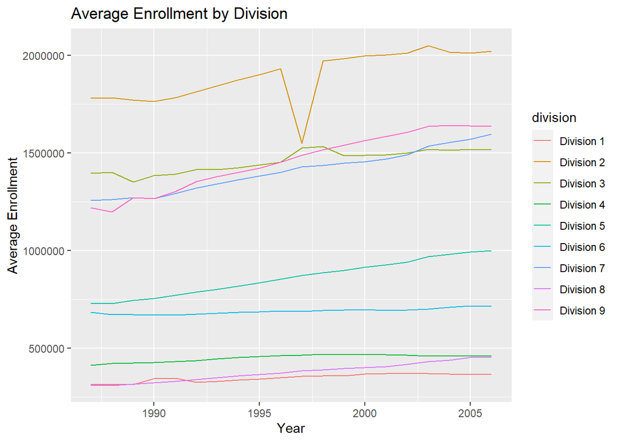

```r
plot.state <- function(.data, var_name = 'Enrollment') {

    out_data <- .data %>%
        filter(division != 'ERROR') %>%
        group_by(year, division) %>%
        summarise(mean = mean(get(var_name)))


    out_plot <- ggplot(out_data, aes(x = year, y = mean, color = division)) +
        geom_line() +
        ggtitle(paste("Average", var_name, "by Division")) +
        xlab("Year") +
        ylab(paste("Average", var_name))

    return(out_plot)


}

#test the plot method on the state data
plot(dat$State, var_name = 'Enrollment')
```

## Summarize County Data

The `plot.county()` function will filter to a set of counties within a single user-provided state, and plot those county-level values by year. This county-level function also allows the user to select the number of counties appearing in the plot, and also if they want the highest or lowest counties for the measure of interest.

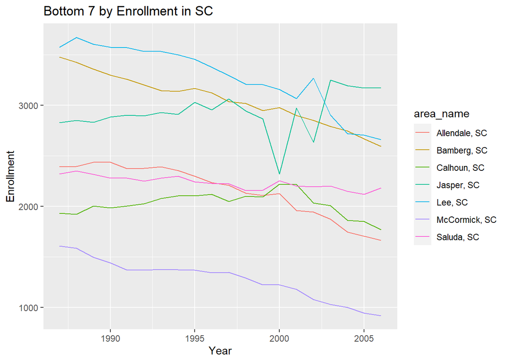

```r
plot.county <- function(.data, state_name = 'SC', var_name = 'Enrollment', order = 'Top', num = 5) {

    #filter the data to the state entered by the user
    state_data <- .data %>%
        filter(state == state_name)

    #get the means of each area for the state
    means <- state_data %>%
        group_by(area_name) %>%
        summarise(mean = mean(get(var_name)))

    #if the user chooses the top most values arrange in descending order
    #limit to the number selected
    if(order == 'Top') {

        plot_order <-  means %>%
            arrange(-mean) %>%
            head(num)
    }

    #if the user chooses the bottom most values arrange in ascending order
    #limit to the number selected
    if(order == 'Bottom') {

        plot_order <- means %>%
            arrange(mean) %>%
            head(num)

    }

    #filter the data set to the top or bottom most areas accordingly
    plot_data <- state_data %>%
        filter(area_name %in% plot_order$area_name)

    #plot the data
    out_plot <- ggplot(plot_data, aes(x = year, y = get(var_name), color = area_name)) +
        geom_line() +
        ylab(var_name) +
        xlab("Year") +
        ggtitle(paste(order, num, "by", var_name, "in", state_name))

    return(out_plot)

}

#test the plot method on the county data
plot(dat$County, order = 'Bottom', num = 7)
```

# Putting it All Together

Now that we have created our function and our generic plotting methods we want to test it out on our data with various conditions

## Testing the Functions and Methods

We will read in and transform the data sets again using our function:

```r
#read in and prep data
EDU01a <- wrapper_function("https://www4.stat.ncsu.edu/~online/datasets/EDU01a.csv")

EDU01b <- wrapper_function("https://www4.stat.ncsu.edu/~online/datasets/EDU01b.csv")
```

Then combine the data into state and county:

```r
#combine datasets into state and county
dat <- list(EDU01a, EDU01b) %>%
   combine_data()
```

And test various plotting parameters

- Plot the state data set

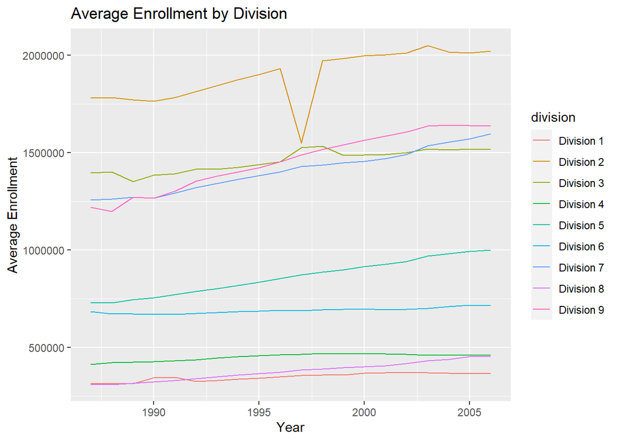

```r
plot(dat$State, var_name = 'Enrollment')
```

- Plot the county data set
  - Specifying the state to be NC, the group to be top, and the number 10
  - Specifying the state to be AZ, the group to be bottom, and the number 6
  - Using default parameters (In our case this is the top 5 counties in South Carolina. Look at what happened when two counties combined their districts in 2006!)
  - Specifying the state to be OH, the group to be top, and the number 8

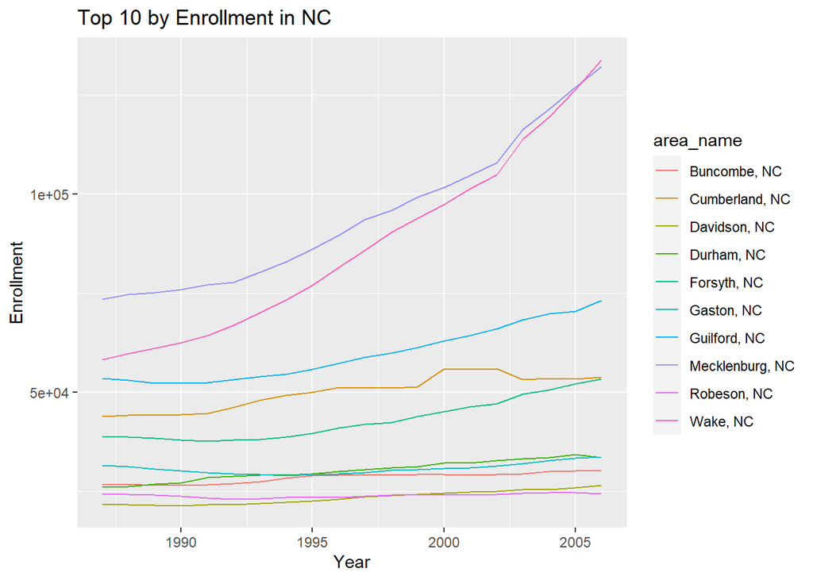

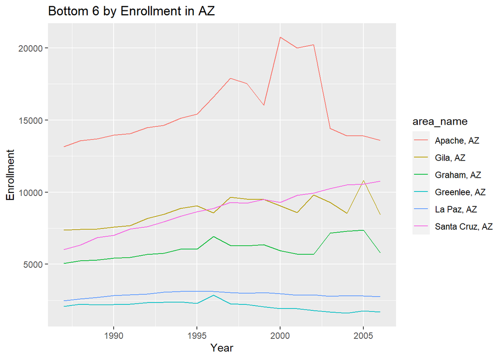

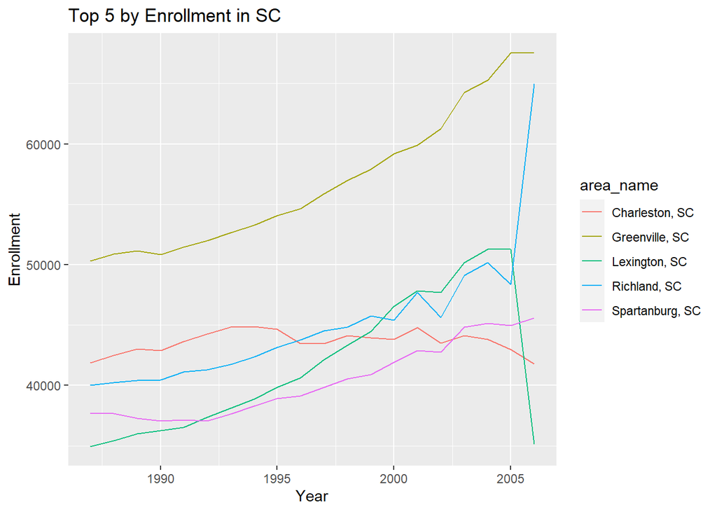

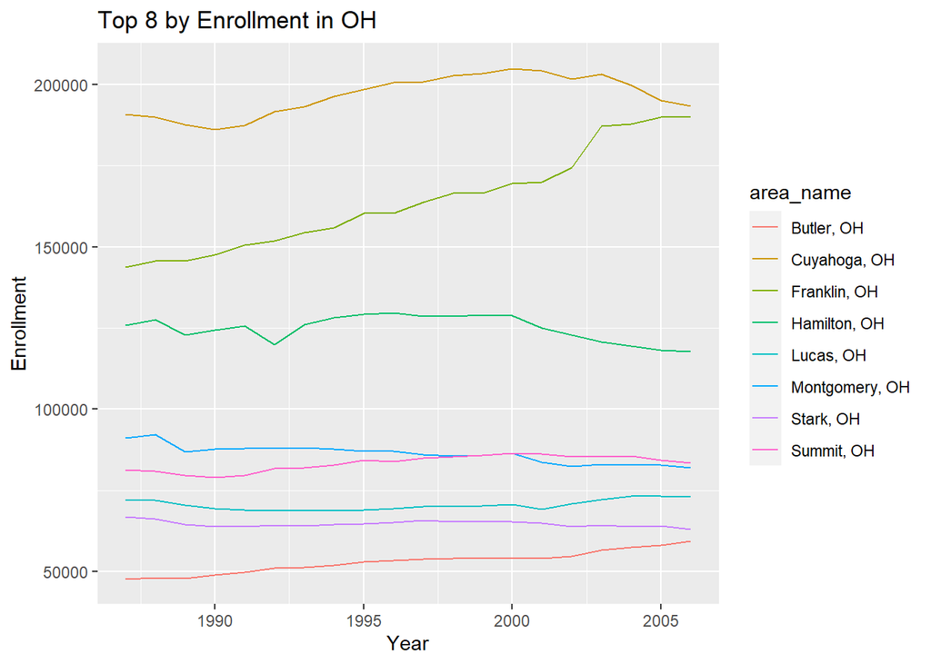

```r
plot(dat$County, state_name = 'NC', order = 'Top', num = 10)
plot(dat$County, state_name = 'AZ', order = 'Bottom', num = 6)
plot(dat$County)
plot(dat$County, state_name = 'OH', order = 'Top', num = 8)
```

## Read in more data

Now we will read in and transform four new data sets using our function:

```r
PST01a <- wrapper_function("https://www4.stat.ncsu.edu/~online/datasets/PST01a.csv")
PST01b <- wrapper_function("https://www4.stat.ncsu.edu/~online/datasets/PST01b.csv")
PST01c <- wrapper_function("https://www4.stat.ncsu.edu/~online/datasets/PST01c.csv")
PST01d <- wrapper_function("https://www4.stat.ncsu.edu/~online/datasets/PST01d.csv")
```

Combine the data sets into County and State:

```r
dat <- list(PST01a, PST01b, PST01c, PST01d) %>%
    combine_data()
```

And again test the plotting methods on various parameters:

- Plot the state data set

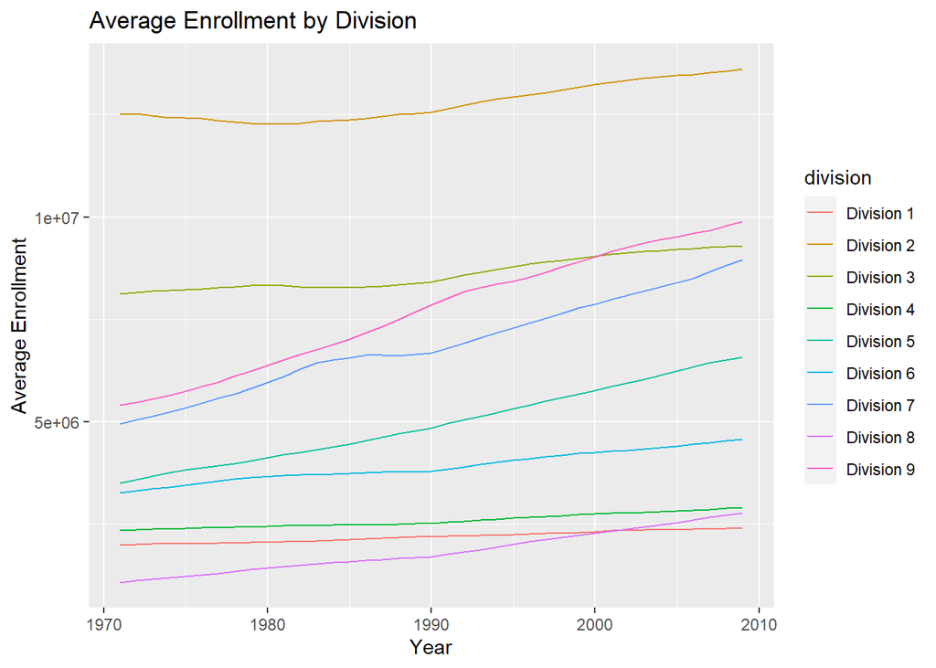

```r
plot(dat$State)
```

- Plot the county data set
  - Specifying the state to be PA, the group to be top, and the number 5
  - Specifying the state to be TX, the group to be bottom, and the number 12
  - Using default parameters
  - Specifying the state to be NY, the group to be top, and the number 6

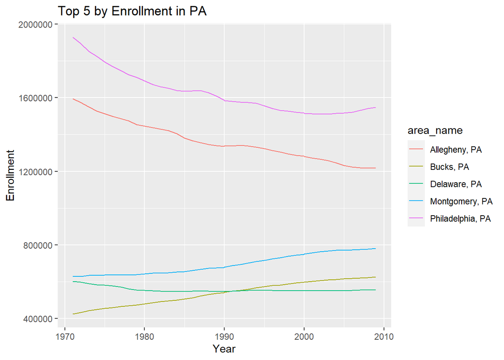

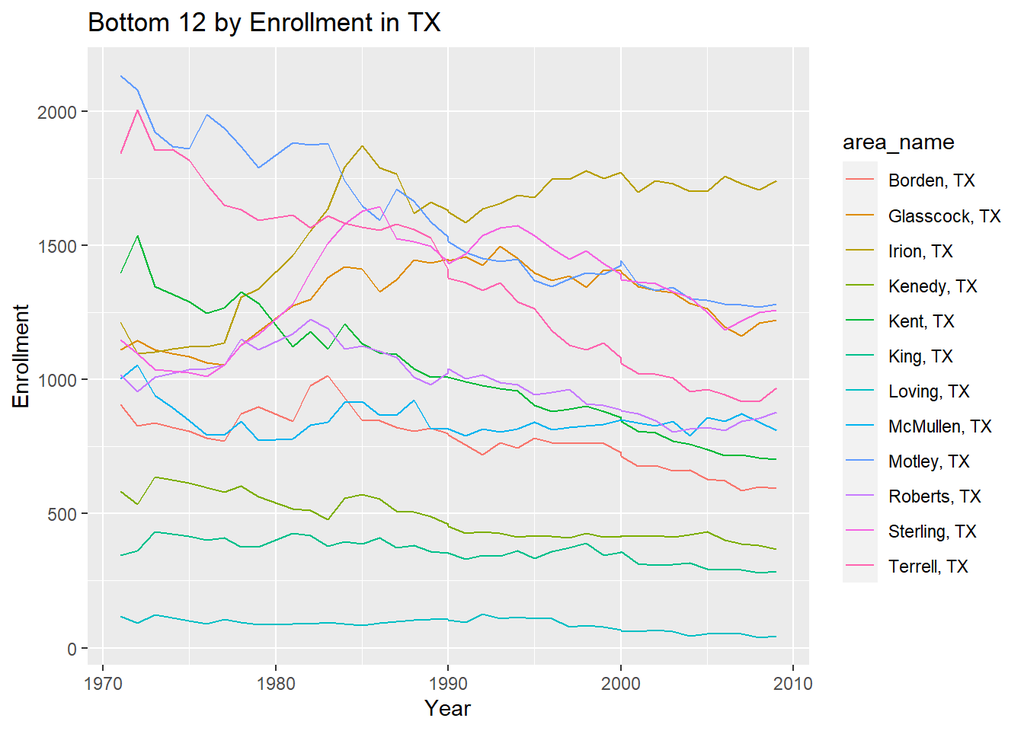

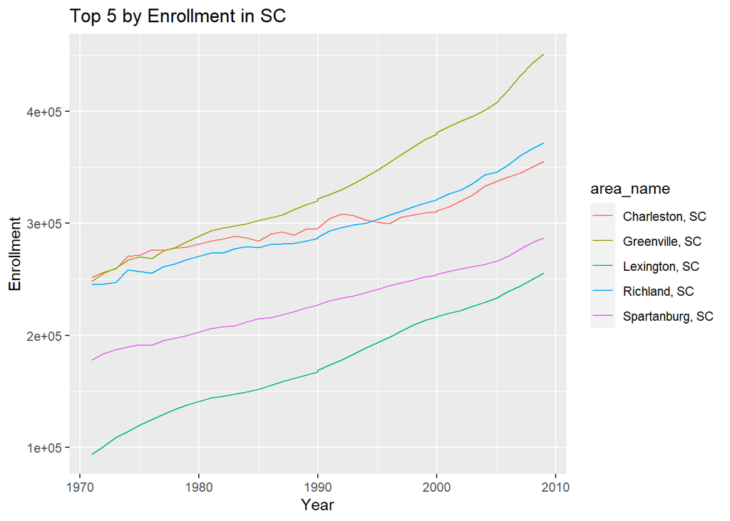

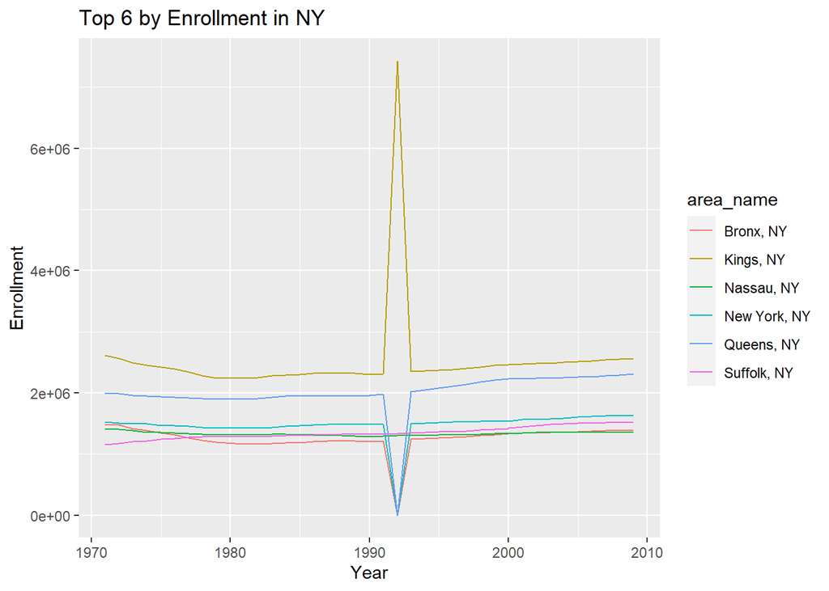

```r
plot(dat$County, state_name = 'PA', order = 'Top', num = 5)
plot(dat$County, state_name = 'TX', order = 'Bottom', num = 12)
plot(dat$County)
plot(dat$County, state_name = 'NY', order = 'Top', num = 6)
```